# 🍷 wine_quality_machine_learning 🥂

## Importing Decision Tree regression Model from SKLEARN for comparision

```python
from sklearn.tree import DecisionTreeRegressor
```

```python
# create a regressor object
regressor = DecisionTreeRegressor(random_state = 0)
regressor.fit(X_train, y_train)
```

```
DecisionTreeRegressor(random_state=0)
```

```python
pred = regressor.predict(X_test)
pred
```

```
array([5.        , 5.        , 7.        , 5.        , 5.        ,
       6.        , 5.        , 6.        , 5.        , 5.        ,
       5.        , 5.        , 6.        , 5.        , 5.        ,
       6.        , 7.        , 5.        , 5.        , 5.        ,
       6.        , 5.        , 6.        , 6.        , 6.        ,
       5.        , 6.        , 7.        , 5.        , 6.        ,
       7.        , 5.        , 5.        , 6.        , 7.        ,
       7.        , 5.        , 5.        , 5.63602251, 7.        ,
       5.        , 6.        , 7.        , 7.        , 6.        ,
       6.        , 5.        , 6.        , 6.        , 6.        ,
       5.        , 5.        , 6.        , 6.        , 6.        ,
       5.        , 5.        , 5.        , 7.        , 6.        ,
       5.        , 6.        , 6.        , 6.        , 5.        ,
       7.        , 5.        , 5.        , 7.        , 6.        ,
       6.        , 5.        , 6.        , 5.        , 5.        ,
       6.        , 5.        , 5.        , 5.        , 7.        ,
       6.        , 5.        , 4.        , 6.        , 6.        ,
       6.        , 6.        , 5.        , 5.        , 5.        ,
       6.        , 6.        , 6.        , 6.        , 5.        ,
       6.        , 6.        , 5.        , 5.        , 6.        ,
       7.        , 7.        , 5.        , 5.63602251, 4.        ,
       5.        , 4.        , 5.        , 6.        , 5.        ,
       6.        , 5.        , 5.63602251, 5.        , 6.        ,
       5.63602251, 6.        , 7.        , 6.        , 6.        ,
       6.        , 5.        , 5.        , 5.        , 6.        ,
       7.        , 6.        , 6.        , 6.        , 6.        ,
       5.        , 5.        , 6.        , 5.63602251, 6.        ,
       5.        , 6.        , 5.        , 6.        , 5.        ,
       6.        , 6.        , 5.        , 6.        , 5.        ,
       6.        , 5.63602251, 6.        , 5.        , 5.        ,
       6.        , 5.        , 5.        , 5.        , 6.        ,
       6.        , 6.        , 6.        , 6.        , 5.        ,
       6.        , 5.        , 7.        , 5.        , 5.        ,
       5.        , 6.        , 7.        , 6.        , 6.        ,
       5.        , 5.        , 4.        , 7.        , 6.        ,
       6.        , 6.        , 5.        , 7.        , 5.        ,
       6.        , 7.        , 6.        , 6.        , 5.        ,
       5.        , 5.        , 5.        , 5.        , 5.        ,
       6.        , 5.        , 6.        , 6.        , 5.        ,
       5.        , 5.        , 6.        , 7.        , 5.        ,
```

[output cut: 25 more lines]

```
       6.        , 7.        , 6.        , 5.        , 5.        ,
       7.        , 4.        , 5.        , 5.        , 5.        ,
       6.        , 7.        , 5.        , 5.        , 7.        ,
       5.        , 6.        , 5.        , 7.        , 6.        ,
       6.        , 5.        , 6.        , 5.        , 6.        ,
       5.        , 7.        , 5.        , 5.        , 7.        ,
       4.        , 6.        , 6.        , 6.        , 7.        ,
       5.        , 6.        , 5.        , 7.        , 6.        ,
       6.        , 5.        , 7.        , 6.        , 6.        ,
       6.        , 5.        , 5.        , 6.        , 5.        ,
       5.        , 5.        , 6.        , 6.        , 6.        ,
       6.        , 6.        , 5.        , 7.        , 5.        ,
       6.        , 5.        , 6.        , 6.        , 5.        ,
       7.        , 6.        , 5.        , 7.        , 4.        ,
       5.        , 4.        , 6.        , 6.        , 5.        ])
```

```python
regressor.score(X_train,y_train)
```

```
1.0
```

```python
regressor.score(X_test,y_test)
```

```
-0.070591855526833
```

```python
from sklearn import  metrics
```

```python
print('MAE',metrics.mean_absolute_error(y_test,pred))
print('MSE',metrics.mean_squared_error(y_test,pred))
print('RMSE',np.sqrt(metrics.mean_squared_error(y_test,pred)))
```

```
MAE 0.44091932457786115
MSE 0.5414212447507647
RMSE 0.7358133219443398
```

```python
metrics.explained_variance_score(y_test,pred)
```

```
-0.06720922603907686
```

# Hyper Parameter tuning

```python
# Hyper parameters range intialization for tuning

parameters={'max_depth': [None, 1, 2, 3, 4],
             'min_samples_split': [2, 3, 4, 5],
             'min_samples_leaf': [1, 2, 3]}
```

Above we intialized hyperparmeters random range using Gridsearch to find the best parameters for our decision tree model.

```python
# calculating different regression metrics

from sklearn.model_selection import GridSearchCV
```

```python
tuning_model=GridSearchCV(regressor,param_grid=parameters,scoring='neg_mean_squared_error',cv=3,verbose=3)
```

```python
# function for calculating how much time take for hyperparameter tuning

def timer(start_time=None):
    if not start_time:
        start_time=datetime.now()
        return start_time
    elif start_time:
        thour,temp_sec=divmod((datetime.now()-start_time).total_seconds(),3600)
        tmin,tsec=divmod(temp_sec,60)
```

```python
%%capture
from datetime import datetime

start_time=timer(None)

tuning_model.fit(X_train,y_train)

timer(start_time)
```

```python
# best hyperparameters
tuning_model.best_params_
```

```
{'max_depth': 3, 'min_samples_leaf': 1, 'min_samples_split': 2}
```

```python
# best model score
tuning_model.best_score_
```

```
-0.4436132691457793
```

# Training Decision Tree With Best Hyperparameter

```python
tuned_hyper_model= DecisionTreeRegressor(max_depth=3, min_samples_leaf=1, min_samples_split=2)
```

```python
# fitting model


tuned_hyper_model.fit(X_train,y_train)
```

```
DecisionTreeRegressor(max_depth=3)
```

```python
# prediction

tuned_pred=tuned_hyper_model.predict(X_test)
```

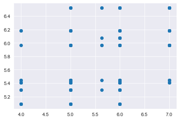

```python
plt.scatter(y_test,tuned_pred)
```

```python
print('MAE:', metrics.mean_absolute_error(y_test,tuned_pred))
print('MSE:', metrics.mean_squared_error(y_test, tuned_pred))
print('RMSE:', np.sqrt(metrics.mean_squared_error(y_test, tuned_pred)))
```

```
MAE: 0.4994172686865808
MSE: 0.39845968462788744
RMSE: 0.6312366312468625
```

```python
print('MAE',metrics.mean_absolute_error(y_test,pred))
print('MSE',metrics.mean_squared_error(y_test,pred))
print('RMSE',np.sqrt(metrics.mean_squared_error(y_test,pred)))
```

```
MAE 0.44091932457786115
MSE 0.5414212447507647
RMSE 0.7358133219443398
```

```python
tuned_hyper_model.score(X_test,y_test)# with hyper parameter tuning
```

```
0.2120965010991025
```

```python
regressor.score(X_test,y_test)# without hyper parameter tuning
```

```
-0.070591855526833
```

```python
metrics.explained_variance_score(y_test,tuned_pred) # with hyper parameter tuning
```

```
0.2204898093971137
```

```python
metrics.explained_variance_score(y_test,pred)# without hyper parameter tuning
```

```
-0.06720922603907686
```

## Implementing this best parameter in our model which we build from scratch

```python
dt_new_reg = ID3DecisionTreeRegressor(max_depth=3, min_sample_leaf=1, min_sample_split=2)
dt_new_reg.fit(X, y)

print("\nTrain RMSE : {}".format(rmse_score(y_train, dt_new_reg.predict(X_train))))
print("\nTest RMSE: {}".format(rmse_score(y_test, dt_new_reg.predict(X_test))))
```

```
Decision Tree(depth = 3) :
 {'chlorides': {'<=0.075': {'chlorides': {'<=0.066': {'chlorides': {'<=0.061': 5.841610912480679, '>0.061': 6.005256384413813}}, '>0.066': 5.667988025431256}}, '>0.075': 5.532268292682928}}

Train RMSE : 0.7351735857683132

Test RMSE: 0.6887389432707641
```

**By tuning the model I got RMSE value of:**

```
                                    1)Train= 0.735


                                    2) Test= 0.688
```

**Without Hyper parameter tuning I got RMSE value of:**

```
                                    1)Train=0.225

                                    2)Test= 0.214

                                    3) Depth = 667
```

# Hyper parameter tuning From Scratch code

```python
from collections import Counter

class GridSearchCV:
    def __init__(self, estimator, param_grid, cv=5):
        self.estimator = estimator
        self.param_grid = param_grid
        self.cv = cv

    def fit(self, data, labels):
        best_score = float('inf')
        for params in self._get_param_combinations():
            scores = []
            for i in range(self.cv):
                train_data, train_labels, val_data, val_labels = self._get_fold(data, labels, i)
                model = self.estimator(**params)
                model.fit(train_data, train_labels)
                score = self._score(model, val_data, val_labels)
                scores.append(score)
            mean_score = np.mean(scores)
            if mean_score > best_score:
                best_score = mean_score
                self.best_params = params
                self.best_estimator = self.estimator(**params)
        self.best_estimator.fit(data, labels)

    def predict(self, data):
        return self.best_estimator.predict(data)

    def _score(self, model, data, labels):
        preds = model.predict(data)
        return -np.mean((labels - preds)**2)

    def _get_fold(self, data, labels, i):
        n_samples = data.shape[0]
        fold_size = n_samples // self.cv
        start = i * fold_size
        end = (i + 1) * fold_size
        val_data = data[start:end]
        val_labels = labels[start:end]
        train_data = np.concatenate([data[:start], data[end:]], axis=0)
        train_labels = np.concatenate([labels[:start], labels[end:]], axis=0)
        return train_data, train_labels, val_data, val_labels

    def _get_param_combinations(self):
        param_combinations = []
        for key in self.param_grid:
            values = self.param_grid[key]
            param_combinations = [dict(zip(self.param_grid.keys(), v)) for v in itertools.product(values, repeat=len(self.param_grid))]
        return param_combinations
```

This is the code for implementing Hyperparameter tuning for regression from scratch in python

```python
grid_search = GridSearchCV(estimator=ID3DecisionTreeRegressor, param_grid=param_grid)
grid_search.fit(X_train, y_train)
print("Best parameters:", grid_search.best_params_)
print("Best score:", grid_search.best_score_)
```

[output not shown]

# Conclusion

In this notebook I took wine quality prediction by Decision Tree Regression using ID3 algorithm from Scratch and comparing my model with Sklearn Decision tree regression and also provided Hyper parameter tuning for model .